# Word Prediction Application

21/05/2022

## Introduction

This is the presentation for **Capstone Project**. This course focuses on analyzes a corpus of text and build a n-gram model to predict next word in sequence

**Contents**

- Text data analysis: analysis of the corpus to understand the relationship of words and word pairs
- Predictive modeling: build basic n-gram models and develop algorithms to facilitate text prediction
- Shiny app development: produce a web-based Shiny app interface to predict next words

## Project

Below steps were followed as part of this project

1. Sampling and cleaning Data - First I sampled the data to use 10% of data for training and subsequently removed profanity so that we don’t predict those
2. Exploratory Data Analysis - Frequency plots for bi-grams, tri-grams were made to observe whether n-gram modelling can be useful
3. Modelling - Backoff model (5 - gram) from sbo package was used to build final model for prediction
4. Shiny - Finally I made Shiny app to build an application for predicting next words in the model

## Shiny Application

Shiny app can be found here - https://rjain92.shinyapps.io/WordPredictionApp/

The app takes in 2 inputs : * query - phrase that the user input for next word prediction * number of predictions

Application will produce a word-cloud with the best prediction shown in largest text with font decreasing with subsequent predictions

## Data Exploration - Frequency plot for bi-grams

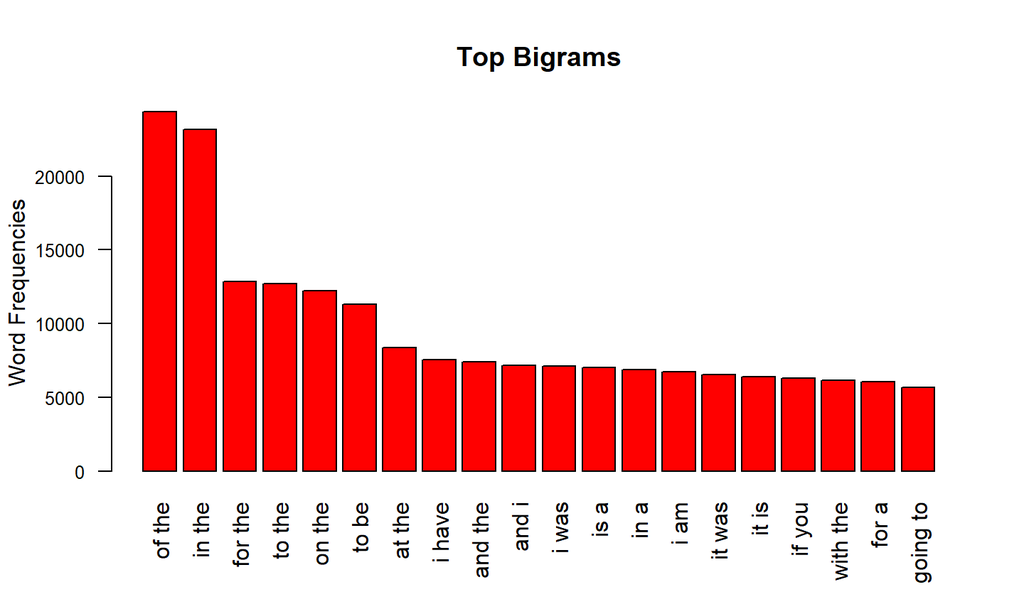

## References

- Github repo for the project - https://github.com/jnrahul92/coursera_capstone_jh_ds
- More about Katz’s Backoff Model - https://en.wikipedia.org/wiki/Katz%27s_back-off_model
- SBO Package Documentation - https://cran.r-project.org/web/packages/sbo/vignettes/sbo.html